# Practical Machine Learning Project

Franklin Lam

21 February, 2015

# Introduction

This project aims to predict the manner in which people using devices such as Jawbone Up, Nike FuelBand, and Fitbit did the exercise. Data from accelerometers on the belt, forearm, arm, and dumbell of 6 participants are collected. They were asked to perform barbell lifts correctly and incorrectly in 5 different ways. Tree-based models including CART model and random forest model were compared and selected for classifying the testing data.

# Data preparation

The training and testing data are downloaded from:

- Training data - https://d396qusza40orc.cloudfront.net/predmachlearn/pml-training.csv
- Testing data - https://d396qusza40orc.cloudfront.net/predmachlearn/pml-testing.csv

The data sets are cleaned by: 1. deleting variables with missing values; and 2. deleting the first observation related variables that are unrelated to the problem.

```r
training_data <- read.csv("pml-training.csv" , na.strings=c("NA",""), header=TRUE)
testing_data <- read.csv("pml-testing.csv" , na.strings=c("NA",""), header=TRUE)
training_data <- training_data[ , apply( training_data , 2 , function(x) all(!is.na(x)) ) ]
testing_data <- testing_data[ , apply( testing_data , 2 , function(x) all(!is.na(x)) ) ]
training_data <- training_data[,-(1:7)]
testing_data <- testing_data[,-(1:7)]
```

A total of 52 variables (excluding the classification variable classe) remains.

```
##  [1] "roll_belt"            "pitch_belt"           "yaw_belt"
##  [4] "total_accel_belt"     "gyros_belt_x"         "gyros_belt_y"
##  [7] "gyros_belt_z"         "accel_belt_x"         "accel_belt_y"
## [10] "accel_belt_z"         "magnet_belt_x"        "magnet_belt_y"
## [13] "magnet_belt_z"        "roll_arm"             "pitch_arm"
## [16] "yaw_arm"              "total_accel_arm"      "gyros_arm_x"
## [19] "gyros_arm_y"          "gyros_arm_z"          "accel_arm_x"
## [22] "accel_arm_y"          "accel_arm_z"          "magnet_arm_x"
## [25] "magnet_arm_y"         "magnet_arm_z"         "roll_dumbbell"
## [28] "pitch_dumbbell"       "yaw_dumbbell"         "total_accel_dumbbell"
## [31] "gyros_dumbbell_x"     "gyros_dumbbell_y"     "gyros_dumbbell_z"
## [34] "accel_dumbbell_x"     "accel_dumbbell_y"     "accel_dumbbell_z"
## [37] "magnet_dumbbell_x"    "magnet_dumbbell_y"    "magnet_dumbbell_z"
## [40] "roll_forearm"         "pitch_forearm"        "yaw_forearm"
## [43] "total_accel_forearm"  "gyros_forearm_x"      "gyros_forearm_y"
## [46] "gyros_forearm_z"      "accel_forearm_x"      "accel_forearm_y"
## [49] "accel_forearm_z"      "magnet_forearm_x"     "magnet_forearm_y"
## [52] "magnet_forearm_z"     "classe"
```

The training data is splitted into a training and testing subset for modelling building:

```r
library(caret)
set.seed(125)
intrain<-createDataPartition(y=training_data$classe,p=0.75,list=FALSE)
train_set <- training_data[intrain,]
test_set <- training_data[-intrain,]
```

# Prediction model

Two tree-based prediction models were developed and compared as follows:

A. CART model

```r
library(caret)
library(rattle)
fit_rpart <- train(classe~.,data=train_set,
                   preProcess=c("center", "scale"),
                   trControl=trainControl(method = "cv", number = 4),
                   method="rpart")
print(fit_rpart, digits=3)
```

```
## CART
##
## 14718 samples
##    52 predictor
##     5 classes: 'A', 'B', 'C', 'D', 'E'
##
## Pre-processing: centered, scaled
## Resampling: Cross-Validated (4 fold)
##
## Summary of sample sizes: 11038, 11038, 11039, 11039
##
## Resampling results across tuning parameters:
##
##   cp      Accuracy  Kappa  Accuracy SD  Kappa SD
##   0.0328  0.509     0.360  0.00901      0.0130
##   0.0596  0.430     0.232  0.07395      0.1243
##   0.1171  0.325     0.062  0.04715      0.0717
##
## Accuracy was used to select the optimal model using  the largest value.
## The final value used for the model was cp = 0.0328.
```

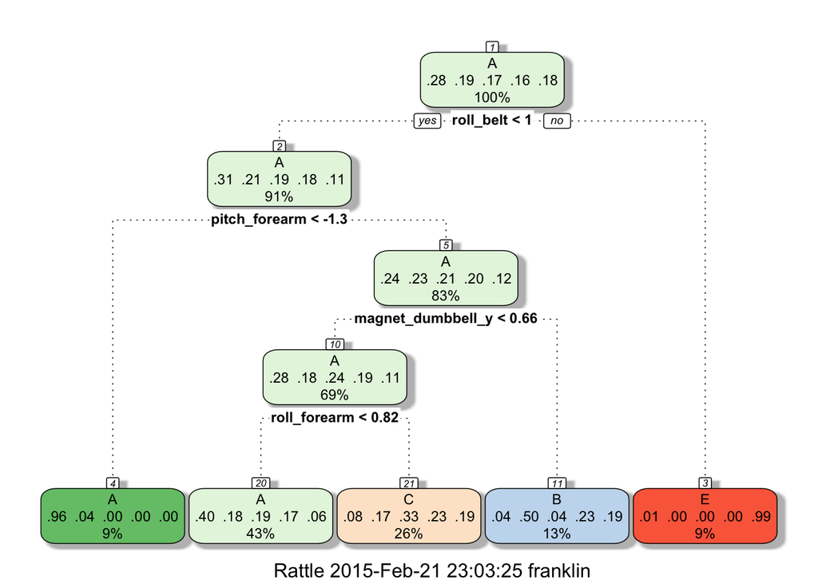

```r
fancyRpartPlot(fit_rpart$finalModel)
```

```r
pred_rpart <- predict(fit_rpart, test_set)
confusionMatrix(pred_rpart, test_set$classe)
```

```
## Confusion Matrix and Statistics
##
##           Reference
## Prediction    A    B    C    D    E
##          A 1286  409  387  341  136
##          B   17  312   26  134  137
##          C   90  228  442  329  242
##          D    0    0    0    0    0
##          E    2    0    0    0  386
##
## Overall Statistics
##
##                Accuracy : 0.4947
##                  95% CI : (0.4806, 0.5088)
##     No Information Rate : 0.2845
##     P-Value [Acc > NIR] : < 2.2e-16
##
##                   Kappa : 0.3395
##  Mcnemar's Test P-Value : NA
##
## Statistics by Class:
##
##                      Class: A Class: B Class: C Class: D Class: E
## Sensitivity            0.9219  0.32877  0.51696   0.0000  0.42841
## Specificity            0.6372  0.92061  0.78044   1.0000  0.99950
## Pos Pred Value         0.5025  0.49840  0.33208      NaN  0.99485
## Neg Pred Value         0.9535  0.85110  0.88441   0.8361  0.88596
## Prevalence             0.2845  0.19352  0.17435   0.1639  0.18373
## Detection Rate         0.2622  0.06362  0.09013   0.0000  0.07871
## Detection Prevalence   0.5218  0.12765  0.27141   0.0000  0.07912
## Balanced Accuracy      0.7795  0.62469  0.64870   0.5000  0.71396
```

B. Random forest model

The random forest model was obtained using the train_set and then evaluated using the test_set giving the following result. The model can achieve much higher accuracy of over 99.29%. The expected out of sample error is equal to 1 - 0.9929 = 0.0071. So, the random forecast model is recommended to be adopted as the prediction model.

```r
library(caret)
library(rattle)
fit_rf <- train(classe~.,data=train_set,
                preProcess=c("center", "scale"),
                trControl=trainControl(method = "cv", number = 4),prox=TRUE,
                method="rf")
print(fit_rf, digits=3)
```

```
## Random Forest
##
## 14718 samples
##    52 predictor
##     5 classes: 'A', 'B', 'C', 'D', 'E'
##
## Pre-processing: centered, scaled
## Resampling: Cross-Validated (4 fold)
##
## Summary of sample sizes: 11037, 11039, 11039, 11039
##
## Resampling results across tuning parameters:
##
##   mtry  Accuracy  Kappa  Accuracy SD  Kappa SD
##    2    0.990     0.987  0.00245      0.00311
##   27    0.991     0.988  0.00370      0.00468
##   52    0.983     0.979  0.00466      0.00590
##
## Accuracy was used to select the optimal model using  the largest value.
## The final value used for the model was mtry = 27.
```

```r
pred_rf <- predict(fit_rf, test_set)
confusionMatrix(pred_rf, test_set$classe)
```

```
## Confusion Matrix and Statistics
##
##           Reference
## Prediction    A    B    C    D    E
##          A 1394    3    0    0    0
##          B    0  942    1    1    0
##          C    1    4  851   12    1
##          D    0    0    3  791    9
##          E    0    0    0    0  891
##
## Overall Statistics
##
##                Accuracy : 0.9929
##                  95% CI : (0.9901, 0.995)
##     No Information Rate : 0.2845
##     P-Value [Acc > NIR] : < 2.2e-16
##
##                   Kappa : 0.991
##  Mcnemar's Test P-Value : NA
##
## Statistics by Class:
##
##                      Class: A Class: B Class: C Class: D Class: E
## Sensitivity            0.9993   0.9926   0.9953   0.9838   0.9889
## Specificity            0.9991   0.9995   0.9956   0.9971   1.0000
## Pos Pred Value         0.9979   0.9979   0.9793   0.9851   1.0000
## Neg Pred Value         0.9997   0.9982   0.9990   0.9968   0.9975
## Prevalence             0.2845   0.1935   0.1743   0.1639   0.1837
## Detection Rate         0.2843   0.1921   0.1735   0.1613   0.1817
## Detection Prevalence   0.2849   0.1925   0.1772   0.1637   0.1817
## Balanced Accuracy      0.9992   0.9961   0.9954   0.9905   0.9945
```

# Conclusions

Two tree-based models, namely CART model and random forest model, were compared using the provided training data. The results show that random forest model outperforms CART model. Therefore, the random forest is the recommended prediction model for the problem.

[output not shown]

The following is the final classification of testing data applying the random forest prediction model with expected out of sample error equal to 0.0071.

```r
library(caret)
library(rattle)
pred_rf <- predict(fit_rf, testing_data)
print(pred_rf)
```

```
##  [1] B A B A A E D B A A B C B A E E A B B B
## Levels: A B C D E
```